# Exp3.Crohn’s_disease_network

2025-12-09

目标：从Intact数据库中下载克罗恩病的人类蛋白互作网络，进行数据清洗并构建`igraph`对象，使用从头实现的MCL聚类和随机游走方法对该网络进行分析。

## 加载包

```r
library(dplyr)
library(yulab.utils)
library(org.Hs.eg.db)
```

```r
library(igraph)
library(TCMDATA)
library(ggplot2)
library(ggtangle)
library(clusterProfiler)
```

## 1. 读取并预处理数据

```r
## load Crohn's disease PPI data from IntAct
intact_data <- read.delim("/Users/hinna/Desktop/nanh/grade4/计算系统生物学/network/Crohn's_disease.txt", sep = "\t", comment.char = "#", header = F)

# 1. 筛选人类互作
human_data <- intact_data %>%
  filter(grepl("taxid:9606", V10) & grepl("taxid:9606", V11))

# 2. 清洗ID前缀
# ("uniprotkb:P12345" -> "P12345")
clean_id <- function(x) {
  # sub("^.*:", "", x)
  return(sub("^.*:", "", x))
}

human_data <- human_data %>%
  mutate(
    Clean_A = clean_id(V1),
    Clean_B = clean_id(V2),
    # "intact-miscore:0.56"
    Score = as.numeric(yulab.utils::str_extract(V15, "[0-9]\\.[0-9]+"))
  )

# 3. ID转换
all_ids <- unique(c(human_data$Clean_A, human_data$Clean_B))
mapped_entrez <- mapIds(
  org.Hs.eg.db,
  keys = all_ids,
  column = "ENTREZID",
  keytype = "UNIPROT",
  multiVals = "first")
id_map_df <- data.frame(
  Original = all_ids,
  Entrez = mapped_entrez,
  stringsAsFactors = FALSE)

id_map_df$Final_ID <- ifelse(is.na(id_map_df$Entrez), id_map_df$Original, id_map_df$Entrez)

final_network_df <- human_data %>%
  left_join(id_map_df, by = c("Clean_A" = "Original")) %>%
  dplyr::rename(ID_A = Final_ID) %>%
  dplyr::select(-Entrez) %>%
  left_join(id_map_df, by = c("Clean_B" = "Original")) %>%
  dplyr::rename(ID_B = Final_ID) %>%
  dplyr::select(ID_A, ID_B, Score) %>%
  dplyr::rename(score = Score)

final_network_df <- final_network_df %>%
  filter(ID_A != ID_B) %>% # 去除自环
  distinct(ID_A, ID_B, .keep_all = TRUE)

head(final_network_df)
```

```
##    ID_A ID_B score
## 1 26191  916  0.35
## 2 26191 3932  0.78
## 3 26191 7409  0.35
## 4 26191 7535  0.60
## 5 26191 7415  0.35
## 6 26191  919  0.63
```

## 2. 构建克罗恩人类蛋白互作网络对象

```r
g <- graph_from_data_frame(d = final_network_df, directed = FALSE)
print(g)
```

```
## IGRAPH 53c140f UN-- 82 111 --
## + attr: name (v/c), score (e/n)
## + edges from 53c140f (vertex names):
##  [1] 26191 --916    26191 --3932   26191 --7409   26191 --7535   26191 --7415
##  [6] 26191 --919    26191 --919    7535  --3932   919   --3932   329   --8737
## [11] 329   --8767   330   --8767   330   --8737   331   --8737   331   --8767
## [16] 331   --11035  329   --11035  330   --11035  331   --P57078 330   --P57078
## [21] 329   --P57078 329   --8767   330   --8737   329   --7321   330   --7321
## [26] P57078--7321   331   --P57078 120892--3842   120892--5518   120892--5717
## [31] 120892--1434   120892--8826   120892--4773   4773  --1434   4773  --3842
## [36] 4773  --8826   4773  --5518   120892--4773   23291 --3454   23291 --3454
## + ... omitted several edges
```

## 3. 分析PPI对象

```r
## 通过置信度筛选节点
g <- ppi_subset(g, score_cutoff = 0.5)

## 计算拓扑指标
g <- compute_nodeinfo(g)
```

```
## Calculating degree / strength ...
```

```
## Calculating betweenness (unweighted) ...
```

```
## Calculating betweenness (weighted) ...
```

```
## Calculating closeness (unweighted) ...
```

```
## Calculating closeness (weighted) ...
```

```
## Calculating eigenvector centrality ...
```

```
## Calculating PageRank ...
```

```
## Calculating coreness (k-core) ...
```

```
## Calculating local clustering coefficient ...
```

```
## Calculating eccentricity ...
```

```
## Detecting articulation points ...
```

```
## Calculating MCC ...
```

```
## Calculating MNC ...
```

```
## Calculating DMNC ...
```

```
## Calculating BottleNeck (BN) ...
```

```
## Calculating radiality ...
```

```
## Calculating Stress ...
```

```
## Calculating EPC ...
```

[output not shown]

## 4. MCL聚类分析

```r
## MCL聚类
# 通过mcl包的结果
g <- TCMDATA::run_MCL(g, inflation = 2.5) # 12 clusters
```

```
## Running MCL with inflation = 2.5 ...
```

```
## Done! Identified 12 modules (Iterations: 51).
```

```r
# 聚类打分
g_res <- TCMDATA::Addclusterscore(g, cluster_attr = "mcl_cluster")
```

```
## Evaluating 12 clusters based on attribute: mcl_cluster
```

```r
print(g_res)
```

```
##   Cluster_ID Score Nodes Edges Density
## 1          1 4.500     5     9   0.900
## 2          2 3.333     4     5   0.833
## 3          3 3.333     4     5   0.833
## 4          8 3.000     3     3   1.000
## 5          4 2.500     5     5   0.500
## 6          6 2.500     9    10   0.278
##                                   Gene_List
## 1              26191, 919, 7535, 3932, 8935
## 2                     329, 330, 8737, 11035
## 3                   331, 8767, P57078, 7187
## 4 P19838-PRO_0000030311, EBI-10057141, 2908
## 5            120892, 4773, 3842, 5717, 1434
## 6             64127, 5987, 7088, 7431, 2590
##                                         Full_Genes
## 1                         26191,919,7535,3932,8935
## 2                               329,330,8737,11035
## 3                             331,8767,P57078,7187
## 4          P19838-PRO_0000030311,EBI-10057141,2908
## 5                       120892,4773,3842,5717,1434
## 6 64127,5987,7088,7431,2590,51024,10524,5529,51079
```

```r
# 通过从头实现的结果
source("/Users/hinna/Desktop/nanh/grade4/计算系统生物学/network/MCL.R")
g1 <- run_MCL(g, inflation = 2.5) # 15 clusters
```

```
## Converged at iteration 7 (Diff: 5.31e-09)
```

```
## Result: Identified 15 clusters.
```

```r
# 聚类打分
g1_res <- TCMDATA::Addclusterscore(g1, cluster_attr = "MCL_cluster")
```

```
## Evaluating 15 clusters based on attribute: MCL_cluster
```

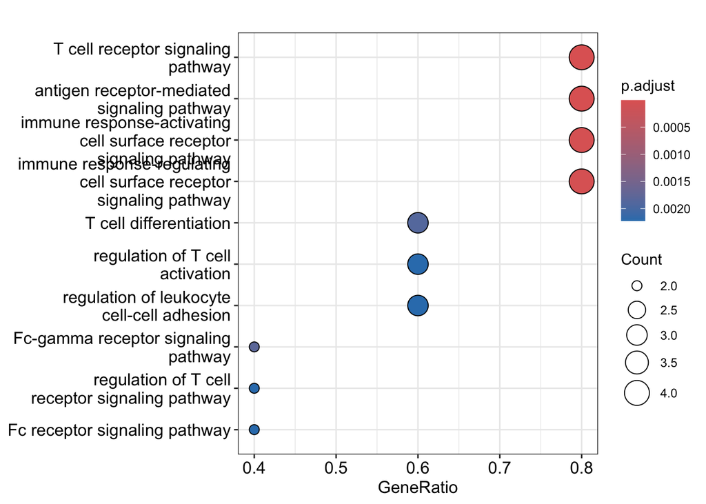

```r
## 选择得分最高的cluster1进行富集分析从而注释该社区的功能
c1_g <- g1_res[1, ]$Full_Genes |> strsplit(",") |> unlist()
c1_bp <- enrichGO(c1_g, ont="BP", OrgDb='org.Hs.eg.db', keyType="ENTREZID")
p1 <- dotplot(c1_bp)
p1
```

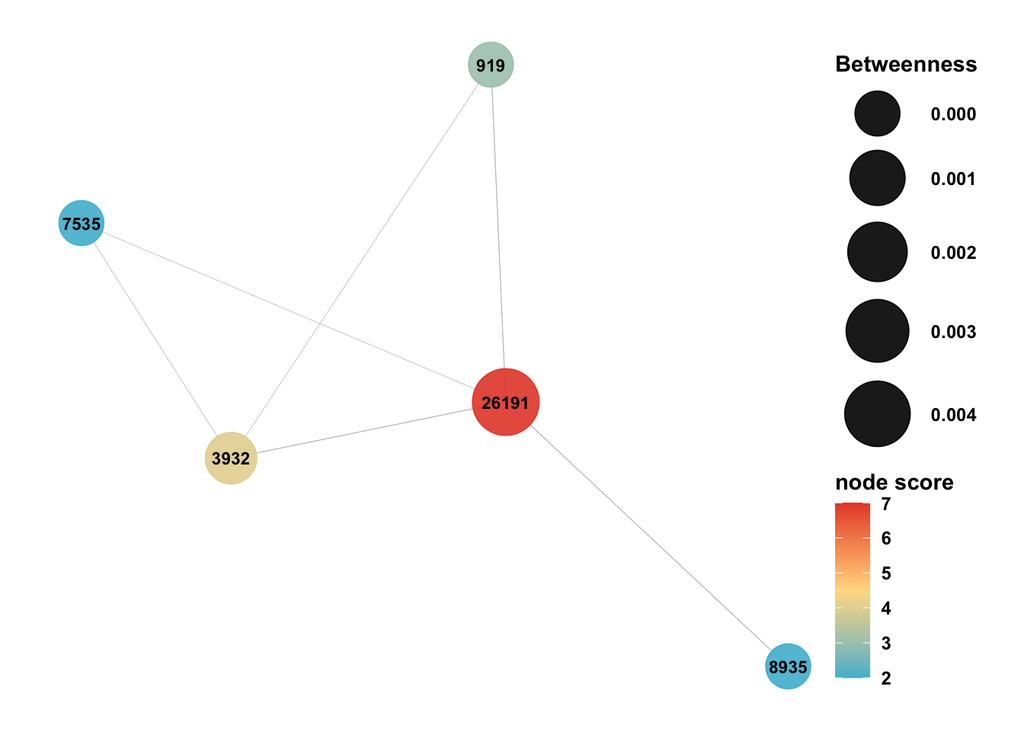

```r
## 选择cluster 1进行可视化
subg_cluster1 <- induced_subgraph(g, vids = c1_g)

p2 <- ggtangle::ggplot(subg_cluster1, layout = "kk") +
  geom_edge(
    colour  = "grey70",
    alpha   = 0.75,
    linewidth = 0.15,
    lineend  = "round"
  ) +
  geom_point(
    aes(colour = degree, size = betweenness),
    alpha = 0.9
  ) +
  geom_text(
    aes(label = name),
    colour      = "black",
    size        = 3,
    fontface    = "bold",
    show.legend = FALSE
  )+
  scale_color_gradientn(
    name    = "node score",
    colours = c("#4DBBD5FF", "#FFDC91", "#E64B35FF"),
    limits  = range(igraph::vertex_attr(subg_cluster1)$degree)
  ) +
  scale_size_continuous(
    name  = "Betweenness",
    range = c(10, 15)
  ) +
  theme_void() +
  theme(
    legend.position = "right",
    legend.title    = element_text(size = 11, face = "bold"),
    legend.text     = element_text(size = 9),
    plot.margin     = unit(c(0.6, 0.8, 0.6, 0.8), "cm"),
    plot.background = element_rect(fill = "white", colour = NA),
    text            = element_text(face = "bold"))

p2
```

## 5. 随机游走分析

```r
## 加载KEGG_T_CELL_RECEPTOR_SIGNALING_PATHWAY基因集进行分析
gene_set <- read.gmt("/Users/hinna/Desktop/nanh/grade4/计算系统生物学/network/c2.cp.kegg_legacy.v2025.1.Hs.entrez.gmt") %>%
  dplyr::filter(term == "KEGG_T_CELL_RECEPTOR_SIGNALING_PATHWAY")

ppi_sets <- intersect(V(g)$name, gene_set$gene)

## 随机游走分析
source("/Users/hinna/Desktop/nanh/grade4/计算系统生物学/network/RWR.R")
g <- run_RWR(g, seed = ppi_sets, score_name = "T_cell_receptor_score")
```

```
## Running RWR with r=0.70. 5/5 seeds found in network.
```

```
## Converged at iteration 12 (Delta: 4.37e-07)
```

```r
res_df <- igraph::as_data_frame(g, what = "vertices")
top_candidates <- res_df %>%
   arrange(desc(T_cell_receptor_score)) %>%
   filter(is_seeds_T_cell_receptor_score == FALSE) %>%
   head(10)
print(top_candidates)
```

```
##          name degree strength betweenness betweenness_w closeness closeness_w
## 26191   26191      7     4.64 0.004471545   0.003658537 1.0000000   0.6477351
## 6772     6772      2     1.08 0.000000000   0.000000000 1.0000000   0.5400000
## 120892 120892      5     2.92 0.007317073   0.007317073 1.0000000   0.5894737
## 8935     8935      2     1.22 0.000000000   0.000000000 0.5714286   0.3605749
## 3842     3842      1     0.60 0.000000000   0.000000000 0.5714286   0.3393939
## 5717     5717      1     0.60 0.000000000   0.000000000 0.5714286   0.3393939
## 1434     1434      1     0.60 0.000000000   0.000000000 0.5714286   0.3393939
## 329       329      5     3.17 0.023623693   0.027439024 0.4444444   0.2923381
## 330       330      5     3.00 0.017351916   0.005487805 0.4444444   0.2903858
## 331       331      3     2.03 0.005365854   0.013414634 0.4000000   0.2998811
##        eigen_centrality   pagerank coreness clustering_coef eccentricity
## 26191      5.193946e-16 0.04439407        3       0.3333333            1
## 6772       9.546020e-17 0.02380952        2       0.0000000            1
## 120892     1.458703e-16 0.05662806        2       0.0000000            1
```

[output cut: 29 more lines]

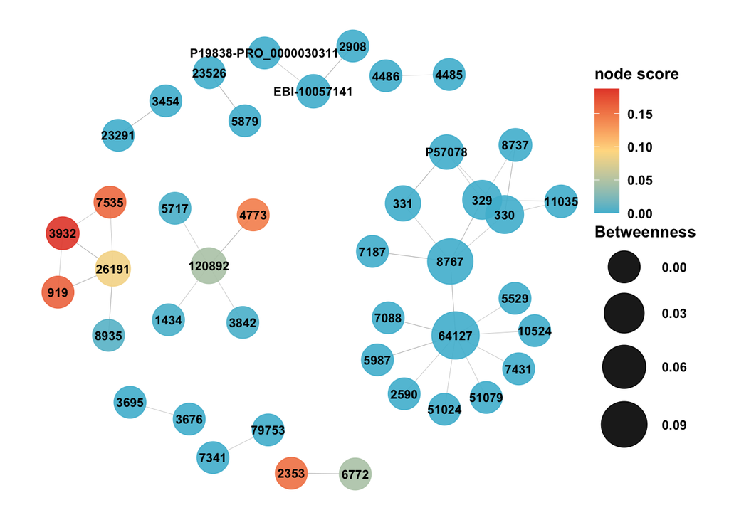

```r
## 可视化随机游走分析结果
p3 <- ggtangle::ggplot(g, layout = "kk") +
  geom_edge(
    colour  = "grey70",
    alpha   = 0.75,
    linewidth = 0.15,
    lineend  = "round"
  ) +
  geom_point(
    aes(colour = T_cell_receptor_score, size = betweenness),
    alpha = 0.9
  ) +
  geom_text(
    aes(label = name),
    colour      = "black",
    size        = 3,
    fontface    = "bold",
    show.legend = FALSE
  )+
  scale_color_gradientn(
    name    = "node score",
    colours = c("#4DBBD5FF", "#FFDC91", "#E64B35FF"),
    limits  = range(igraph::vertex_attr(g)$T_cell_receptor_score)
  ) +
  scale_size_continuous(
    name  = "Betweenness",
    range = c(10, 15)
  ) +
  theme_void() +
  theme(
    legend.position = "right",
    legend.title    = element_text(size = 11, face = "bold"),
    legend.text     = element_text(size = 9),
    plot.margin     = unit(c(0.6, 0.8, 0.6, 0.8), "cm"),
    plot.background = element_rect(fill = "white", colour = NA),
    text            = element_text(face = "bold"))

p3
```